# Predictive Machine Learning

kts

Tuesday, February 17, 2015

### Executive Overview

We were asked to build a predicitive model to assess whether subjects were performing barbell lifts properly, based on sensors mounted on their belt, forearm, arm, and on the dumbell itself. We performed some exploratory data analysis to get an idea of what the data looked like, and built several models as we went. Presented here is the final model, which testing shows to be accurate about 89% of the time.

### Initial Data Load

Some steps to get the data ready for use. Fortunately this was a nice, tidy data set and didn’t require significant cleaning.

```r
#Load useful libraries - in this case only caret is needed.
library(caret)
#set the seed for reproducability
set.seed(1)
#read in the data - in this case, previously downloaded and stored in the working directory.
pml <- read.csv("pml-training.csv")
#separate the data into training and testing sets.
inTrain <- createDataPartition(y<-pml$classe, p=.8, list=FALSE)
training <- pml[inTrain,]
testing <- pml[-inTrain,]
#Also load in the 20 values for submission back to Coursera
test  <- read.csv("pml-testing.csv")
```

### Exploratory Data Analysis

We won’t show the entire output here, but running “summary(pml)” indicated that the roll, pitch, yaw, and total_accel values were well populated; and we took a guess that these would be good values to look at in building our model. We did some featurePlots to confirm this assumption.

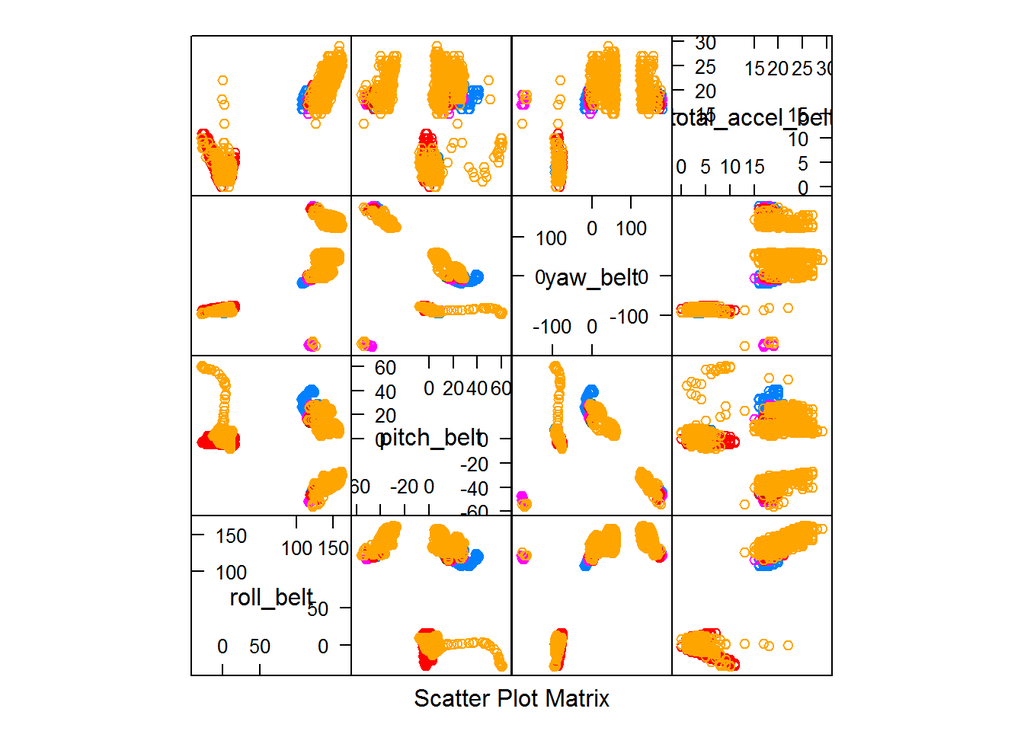

```r
featurePlot(x=training[,c("roll_belt","pitch_belt","yaw_belt","total_accel_belt")], y=training$classe,plot = "pairs")
```

Note that the plot above does appear to indicate some separation between the different performance classes, indicating that these variables are good candidates for predictors.

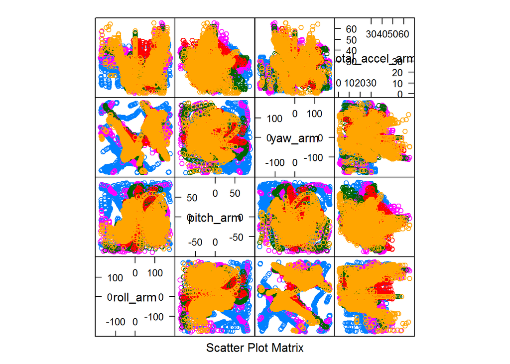

```r
featurePlot(x=training[,c("roll_arm","pitch_arm","yaw_arm","total_accel_arm")], y=training$classe,plot = "pairs")
```

## Model Training and Selection

```r
#Set uo for cross validation.
train_control <- trainControl(method="cv", number=10)

#Some of the previous models that we built.  We found that adding additional variables increased the accuracy of the prediction.

#model <- train(classe~roll_belt+pitch_belt+yaw_belt+total_accel_belt, method="ctree", data = training)
#model <- train(classe~roll_belt+pitch_belt+yaw_belt+total_accel_belt+roll_arm+pitch_arm+yaw_arm+total_accel_arm+roll_dumbbell+pitch_dumbbell+yaw_dumbbell+total_accel_dumbbell, method="ctree", data = training)

#The final model - cross validated to show about 87% accuracy.
model <- train(classe~roll_belt+pitch_belt+yaw_belt+total_accel_belt+roll_arm+pitch_arm+yaw_arm+total_accel_arm+roll_dumbbell+pitch_dumbbell+yaw_dumbbell+total_accel_dumbbell+roll_forearm+pitch_forearm+yaw_forearm+total_accel_forearm, method="ctree", trControl=train_control, data = training)
```

### Model Results

```r
model$results
```

```
##   mincriterion  Accuracy     Kappa AccuracySD    KappaSD
## 1         0.01 0.8680815 0.8330972 0.01261736 0.01591992
## 2         0.50 0.8663618 0.8309220 0.01246267 0.01572925
## 3         0.99 0.8515197 0.8121506 0.01316649 0.01665626
```

Note that the results from cross-validation indicate ~87% accuracy in the final model.

### Test Accuracy on using testing data set

We kept some data back for testing, and generated a confusion matrix to show the results.

```r
predictions <- predict(model, testing[,-160])
confusionMatrix(predictions, testing$classe)
```

```
## Confusion Matrix and Statistics
##
##           Reference
## Prediction    A    B    C    D    E
##          A 1039   46    9   19    5
##          B   41  638   26   12   52
##          C   14   38  615   23   16
##          D   11   23   27  568   24
##          E   11   14    7   21  624
##
## Overall Statistics
##
##                Accuracy : 0.8881
##                  95% CI : (0.8778, 0.8978)
##     No Information Rate : 0.2845
##     P-Value [Acc > NIR] : < 2.2e-16
##
##                   Kappa : 0.8585
##  Mcnemar's Test P-Value : 4.853e-05
##
## Statistics by Class:
##
##                      Class: A Class: B Class: C Class: D Class: E
## Sensitivity            0.9310   0.8406   0.8991   0.8834   0.8655
## Specificity            0.9719   0.9586   0.9719   0.9741   0.9834
## Pos Pred Value         0.9293   0.8296   0.8711   0.8698   0.9217
## Neg Pred Value         0.9725   0.9616   0.9786   0.9771   0.9701
## Prevalence             0.2845   0.1935   0.1744   0.1639   0.1838
## Detection Rate         0.2648   0.1626   0.1568   0.1448   0.1591
## Detection Prevalence   0.2850   0.1960   0.1800   0.1665   0.1726
## Balanced Accuracy      0.9514   0.8996   0.9355   0.9287   0.9245
```

### Generate Submissions

```r
outcomes <- predict(model,test)
```